# Statistic inference lecture

Kirill Setdekov

March 10, 2019

## Introduction

“Generating conclusions about a populations from a noisy sample”

*pick frequentist paradigm.* [link to main repository](https://github.com/ksetdekov/courses/tree/master/06_StatisticalInference)

## Probability

$$P(A\cup B)=P(A)+P(B)$$

$$P(A \cup B)=P(A)+P(B)-P(A \cap B)$$

## probability mass function and density function

- PMF
  - must be larger or equal to 0
  - the sum of possible values sum up to 1
- PDF
  - must be larger or equal to 0
  - the sum of possible values sum up to 1. Area under PDFs correspond to probabilities for that random variables

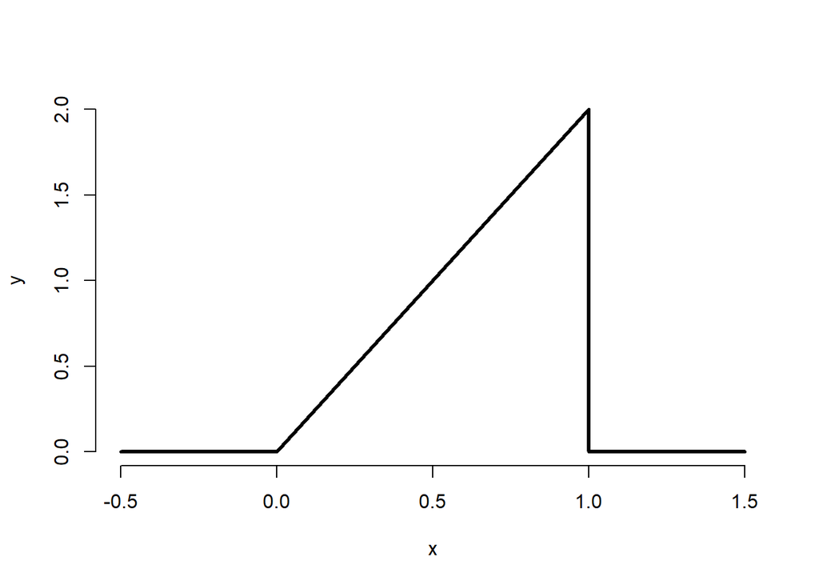

```r
x <- c(-0.5,0,1,1,1.5)
y <- c(0,0,2,0,0)
plot(x,y, lwd=3, frame = FALSE, type="l")
```

## CDF and survival function

- The **cumulative distribution function** (CDF) of a random variable $X$ is defined as the function
  $$F(x) = P(X \leq x)$$
- This definition applies regardless of whether $X$ is discrete or continuous.
- The **survival function** of a random variable $X$ is defined as
  $$S(x) = P(X > x)$$
- Notice that $S(x) = 1 - F(x)$
- For continuous random variables, the PDF is the derivative of the CDF

$$S(x) = 1 - x^2$$

```r
pbeta(c(0.4, 0.5, 0.6), 2, 1)
```

```
## [1] 0.16 0.25 0.36
```

## Quantiles

You’ve heard of sample quantiles. If you were the 95th percentile on an exam, you know that 95% of people scored worse than you and 5% scored better. These are sample quantities. Here we define their population analogs.

## Definition

The $\alpha^{th}$ **quantile** of a distribution with distribution function $F$ is the point $x_\alpha$ so that
$$F(x_\alpha) = \alpha$$
- A **percentile** is simply a quantile with $\alpha$ expressed as a percent - The **median** is the $50^{th}$ percentile

## Example

What is the median of the distribution that we were working with before? - We want to solve $0.5 = F(x) = x^2$ - Resulting in the solution

```r
sqrt(0.5)
```

```
## [1] 0.7071068
```

- Therefore, about 0.7071068 of calls being answered on a random day is the median.

## Example continued

R can approximate quantiles for you for common distributions

```r
qbeta(0.5, 2, 1) #quantiles
```

```
## [1] 0.7071068
```

## summary

- We’re referring to are **population quantities**. Therefore, the median being discussed is the **population median**.
- A probability model connects the data to the population using assumptions.
- Therefore the median we’re discussing is the **estimand**, the sample median will be the **estimator**

# conditinal probabilities

## Conditional probability, definition

- Let $B$ be an event so that $P(B) > 0$
- Then the conditional probability of an event $A$ given that $B$ has occurred is
  $$P(A ~|~ B) = \frac{P(A \cap B)}{P(B)}$$
- Notice that if $A$ and $B$ are independent (defined later in the lecture), then
  $$P(A ~|~ B) = \frac{P(A) P(B)}{P(B)} = P(A)$$

## bayes’ rule

## Bayes’ rule Baye’s rule allows us to reverse the conditioning set provided that we know some marginal probabilities
$$P(B ~|~ A) = \frac{P(A ~|~ B) P(B)}{P(A ~|~ B) P(B) + P(A ~|~ B^c)P(B^c)}.$$

## Diagnostic tests

- Let $+$ and $-$ be the events that the result of a diagnostic test is positive or negative respectively
- Let $D$ and $D^c$ be the event that the subject of the test has or does not have the disease respectively
- The **sensitivity** is the probability that the test is positive given that the subject actually has the disease, $P(+ ~|~ D)$
- The **specificity** is the probability that the test is negative given that the subject does not have the disease, $P(- ~|~ D^c)$

## More definitions

- The **positive predictive value** is the probability that the subject has the disease given that the test is positive, $P(D ~|~ +)$
- The **negative predictive value** is the probability that the subject does not have the disease given that the test is negative, $P(D^c ~|~ -)$
- The **prevalence of the disease** is the marginal probability of disease, $P(D)$

## More definitions

- The **diagnostic likelihood ratio of a positive test**, labeled $DLR_+$, is $P(+ ~|~ D) / P(+ ~|~ D^c)$, which is the
  $$sensitivity / (1 - specificity)$$
- The **diagnostic likelihood ratio of a negative test**, labeled $DLR_-$, is $P(- ~|~ D) / P(- ~|~ D^c)$, which is the
  $$(1 - sensitivity) / specificity$$

## Independence

- Two events $A$ and $B$ are **independent** if
  $$P(A \cap B) = P(A)P(B)$$
- Equivalently if $P(A ~|~ B) = P(A)$
- Two random variables, $X$ and $Y$ are independent if for any two sets $A$ and $B$
  $$P([X \in A] \cap [Y \in B]) = P(X\in A)P(Y\in B)$$
- If $A$ is independent of $B$ then
- $A^c$ is independent of $B$
- $A$ is independent of $B^c$
- $A^c$ is independent of $B^c$

## The population mean

- The **expected value** or **mean** of a random variable is the center of its distribution
- For discrete random variable $X$ with PMF $p(x)$, it is defined as follows
  $$E[X] = \sum_x xp(x).$$
  where the sum is taken over the possible values of $x$
- $E[X]$ represents the center of mass of a collection of locations and weights, $\{x, p(x)\}$

## Example

- Your campaign advisor told you that in a random sample of 100 likely voters, 56 intent to vote for you.
- Can you relax? Do you have this race in the bag?
- Without access to a computer or calculator, how precise is this estimate?
- `1/sqrt(100)=.1` so a back of the envelope calculation gives an approximate 95% interval of `(0.46, 0.66)`
- Not enough for you to relax, better go do more campaigning!
- Rough guidelines, 100 for 1 decimal place, 10,000 for 2, 1,000,000 for 3.

```r
round(1 / sqrt(10 ^ (1 : 6)), 3)
```

```
## [1] 0.316 0.100 0.032 0.010 0.003 0.001
```

### R code

```r
0.56+c(-1,1)*qnorm(0.975)*sqrt(0.56*0.44/100)
```

```
## [1] 0.4627099 0.6572901
```

```r
binom.test(56,100)
```

```
##
##  Exact binomial test
##
## data:  56 and 100
## number of successes = 56, number of trials = 100, p-value = 0.2713
## alternative hypothesis: true probability of success is not equal to 0.5
## 95 percent confidence interval:
##  0.4571875 0.6591640
## sample estimates:
## probability of success
##                   0.56
```

# consider a simulation - bootstrap test

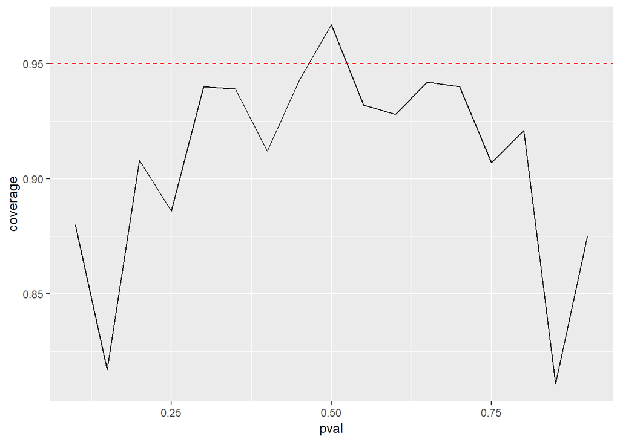

```r
n <- 20
pval <- seq(0.1,0.9, by=0.05)
nosim <- 1000
coverage <- sapply(pval, function(p){
 phat <- rbinom(nosim, prob = p, size = n)/n
 lowerlimit <- phat-qnorm(0.975)*sqrt(phat*(1-phat)/n)
 upperlimit <- phat+qnorm(0.975)*sqrt(phat*(1-phat)/n)
 mean(lowerlimit<p&upperlimit>p)
})
qplot(pval,coverage, geom = "line")+geom_hline(yintercept=0.95,linetype="dashed", color = "red")
```

quick fix - form the interval with Agresti/Coull interval. Add 2 successes and faulures
$$\frac{X+2}{n+4}$$

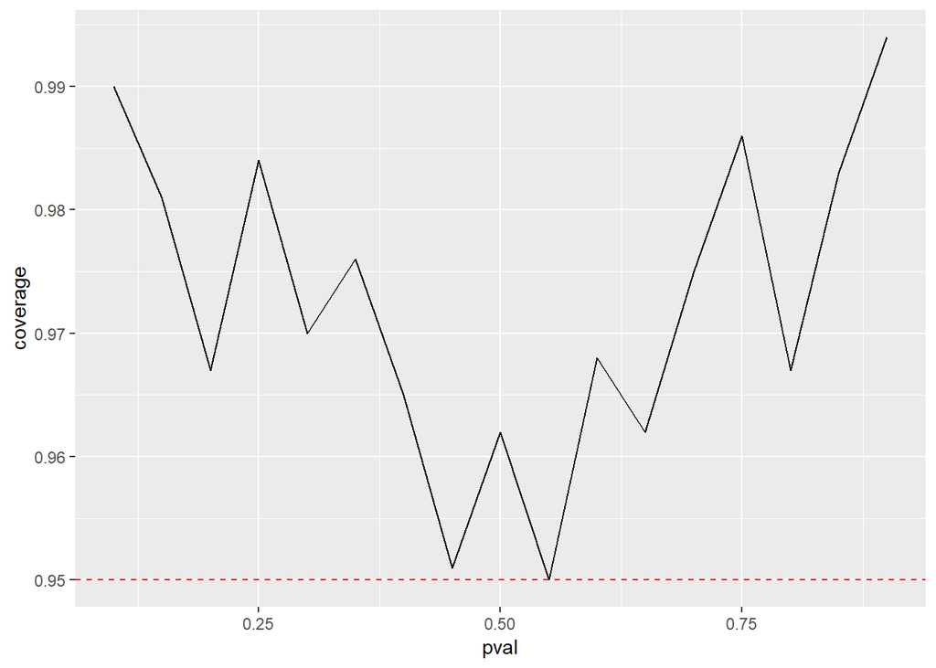

```r
n <- 20
pval <- seq(0.1,0.9, by=0.05)
nosim <- 1000
coverage <- sapply(pval, function(p){
 phat <- (rbinom(nosim, prob = p, size = n)+2)/(n+4)
 lowerlimit <- phat-qnorm(0.975)*sqrt(phat*(1-phat)/n)
 upperlimit <- phat+qnorm(0.975)*sqrt(phat*(1-phat)/n)
 mean(lowerlimit<p&upperlimit>p)
})
qplot(pval,coverage, geom = "line")+geom_hline(yintercept=0.95,linetype="dashed", color = "red")
```

## Poisson interval

- A nuclear pump failed 5 times out of 94.32 days, give a 95% confidence interval for the failure rate per day?
- $X \sim Poisson(\lambda t)$.
- Estimate $\hat \lambda = X/t$
- $Var(\hat \lambda) = \lambda / t$

$$\frac{\hat \lambda - \lambda}{\sqrt{\hat \lambda / t}} =
\frac{X - t \lambda}{\sqrt{X}}
\rightarrow N(0,1)$$
* This isn’t the best interval. * There are better asymptotic intervals. * You can get an exact CI in this case.

### R code

```r
x <- 5; t <- 94.32; lambda <- x / t
round(lambda + c(-1, 1) * qnorm(.975) * sqrt(lambda / t), 3)
```

```
## [1] 0.007 0.099
```

```r
poisson.test(x, T = 94.32)$conf
```

```
## [1] 0.01721254 0.12371005
## attr(,"conf.level")
## [1] 0.95
```

# simulatea a poisson coverage

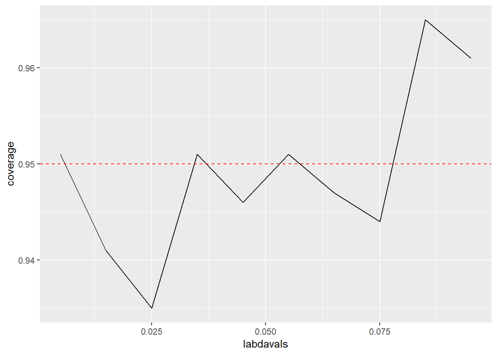

```r
labdavals <- seq(0.005, 0.1, by = 0.01)
nosim <- 1000
t <- 10000
coverage <- sapply(labdavals, function(lambda) {
    lhat <- rpois(nosim, lambda = lambda * t) / t
    lowerlimit <- lhat - qnorm(0.975) * sqrt(lhat / t)
    upperlimit <- lhat + qnorm(0.975) * sqrt(lhat / t)
    mean(lowerlimit < lambda & upperlimit > lambda)
})
qplot(labdavals,coverage, geom = "line")+geom_hline(yintercept=0.95,linetype="dashed", color = "red")
```

## In the regression class

```r
exp(confint(glm(x ~ 1 + offset(log(t)), family = poisson(link = log))))
```

```
##        2.5 %       97.5 %
## 0.0001792718 0.0010746298
```

# summary

- lln states that averages of iid sample converges to the population means that they are estimating.
- the CLT states that averages are approximatesly normal with distributions
  - centerd at population mean
  - $SD$ equal to standard error of the mean
  - CLT gives no guarantee that $n$ is large enough
- Poisso and binomial case have exact intervals that do not require the CLT
  - but a quick fix for small sample size for binomial is to add to fails and 2 successes

for the test You flip a fair coin 5 times, about what’s the probability of getting 4 or 5 heads?

```r
choose(5,5)*.5^5+choose(5,4)*.5^5
```

```
## [1] 0.1875
```

The respiratory disturbance index (RDI), a measure of sleep disturbance, for a specific population has a mean of 15 (sleep events per hour) and a standard deviation of 10. They are not normally distributed. Give your best estimate of the probability that a sample mean RDI of 100 people is between 14 and 16 events per hour?

```r
pnorm(16, mean = 15, sd = 10/sqrt(100)) - pnorm(14, mean = 15, sd = 10/sqrt(100))
```

```
## [1] 0.6826895
```